# NYC Council Data Science Test - CODE and APPENDIX

Caffrey Lee

2020-01-18

```r
library(prettydoc)
library(data.table)
library(DT)
library(ggplot2)
library(scales)
library(xts)
library(zoo)
library(forecast)
library(tseries)
library(formulaic)
#library(ggseas)
library(ggthemes)
library(ggmap)
library(stddiff)
```

```r
dat = fread("NYPD_Arrests_Data__Historic_.csv")
pop = fread('New_York_City_Population_by_Borough__1950_-_2040.csv') # this is modified version and uses the uniformed total population of 2010 for across the year.
setnames(pop, old = c('V1', 'V2'), new = c('arrest_boro', '2010_ pop'))
pop[, total:= sum(`2010_ pop`)]
```

```r
basic.stat <- function(dat){
  print(hist(dat))
  quantile(dat)
}

length.unique <- function(dat, value.name, by = NA){
  require(data.table)
  this.dat <- setDT(x = dat)

  if(length(by) > 0){
    if(!is.na(by[1])){
      if(by[1] == ""){
        by[1] <- NA
      }
    }
  }

  if(is.na(by[1])){
    dat.u <- unique(this.dat, by = value.name)
    ans <- dat.u[, .(N = .N)]
  }
  if(!is.na(by[1])){
    dat.u <- unique(this.dat, by = c(by, value.name))
    ans <- dat.u[, .N, by = by]
  }
  return(ans)
}


round.numerics <- function(x, digits = 3){
  if(is.numeric(x)){
    x <- round(x = x, digits = digits)
  }
  return(x)
}

create.histogram <- function(dat, title, show.labels = T)
{
  if(show.labels == T){
    ggplot(data = dat, aes(x = yr, y = perc)) +
    geom_bar(stat = 'identity', aes(fill = target), colour = 'black', width = 0.6)+
    facet_wrap(~ target) +
    scale_fill_brewer(palette = "Spectral") +
    geom_text(aes(label = paste0(perc*100," %")), vjust = -0.5,  size = 4) +
    theme(legend.position = "top") +
    xlab("Year") +
    ylab("The rates") +
    ggtitle(sprintf("Arrest Rates by %s", title))
  } else {
    ggplot(data = dat, aes(x = yr, y = perc)) +
    geom_bar(stat = 'identity', aes(fill = target), colour = 'black', width = 0.6)+
    facet_wrap(~ target) +
    scale_fill_brewer(palette = "Spectral") +
    theme(legend.position = "top") +
    xlab("Year") +
    ylab("The rates") +
    ggtitle(sprintf("Arrest Rates by %s", title))
  }
}

create.slop.chart <- function(dat, title){
  theme_set(theme_classic())

  dat.2015 = dat[yr == min(dat$yr),]
  dat.2018 = dat[yr == max(dat$yr),]
  dat.condensed = merge(dat.2015[, c(2,5)], dat.2018[, c(2,5)], by = 'target')
  setnames(dat.condensed, old = c('perc.x', 'perc.y'), new = c(as.character(min(dat$yr)), as.character(max(dat$yr))))

  left= paste(min(dat$yr), dat.condensed$target,paste0( (dat.condensed$`2015`)*100, " %"), sep= ', ')
  right= paste(max(dat$yr), dat.condensed$target,paste0( (dat.condensed$`2018`)*100, " %"), sep= ', ')

  dat.condensed$class = ifelse((dat.condensed$`2015` - dat.condensed$`2018`) < 0, 'green', 'red')


  plot =
    ggplot(dat.condensed) + geom_segment(aes(x=1, xend=2, y= `2015`, yend=`2018`, col= class), size=.75, show.legend=F) +
                  geom_vline(xintercept=1, linetype="dashed", size=.1) +
                  geom_vline(xintercept=2, linetype="dashed", size=.1) +
                  scale_color_manual(labels = c("Up", "Down"),
                                     values = c("green"="#00ba38", "red"="#f8766d")) +
                  labs(x="", y=sprintf("Rate by %s", title)) +
    xlim(.5, 2.5)


  # Add texts
  plot = plot + geom_text(label=left, y= dat.condensed$`2015`, x=rep(1, NROW(dat.condensed)), hjust=1.1, size=3.5)
  plot = plot + geom_text(label=right, y= dat.condensed$`2018`, x=rep(2, NROW(dat.condensed)), hjust=-.1, size=3.5)

  plot = plot + geom_text(label="Beginning", x=1, y=1.1*(max(dat.condensed$`2015`, dat.condensed$`2018`)), hjust=1.2, size=3)

  plot = plot + geom_text(label="Ending", x=1, y=1.1*(max(dat.condensed$`2015`, dat.condensed$`2018`)), hjust=1.2, size=3)

  plot + theme(panel.background = element_blank(),
           panel.grid = element_blank(),
           axis.ticks = element_blank(),
           axis.text.x = element_blank(),
           panel.border = element_blank(),
           plot.margin = unit(c(1,2,1,2), "cm"))
  print(plot)
}

ssacf <- function(x){
  sum(acf(x, na.action = na.omit)$acf^2)
}# reference: https://www.r-bloggers.com/is-my-time-series-additive-or-multiplicative/


compare_ssacf <-function(add,mult){
  ifelse(ssacf(add) < ssacf(mult), "Additive", "Multiplicative")
}
# reference: https://www.r-bloggers.com/is-my-time-series-additive-or-multiplicative/

my.format <- function(x, big.mark = ","){
  return(format(x = x, big.mark = big.mark))
}
```

## Introduction

*The purpose of this document is for the NYC Council Data Science Interview. It is done by Caffrey Lee solely.*

### Description of the given data:

The given data contain the individual record of the arrest with the following number of observation and the number of features: 4798339 number of observations and 18.

```r
datatable(pop, caption = 'This is modified manually for the analysis')
```

|  | arrest_boro | 2010_ pop | total |
| --- | --- | --- | --- |
| 1 | B | 1385108 | 8242624 |
| 2 | K | 2552911 | 8242624 |
| 3 | M | 1585873 | 8242624 |
| 4 | Q | 2250002 | 8242624 |
| 5 | S | 468730 | 8242624 |

### Exploring the data:

```r
# exploring the data
names(dat)
```

```
 [1] "ARREST_KEY"        "ARREST_DATE"       "PD_CD"
 [4] "PD_DESC"           "KY_CD"             "OFNS_DESC"
 [7] "LAW_CODE"          "LAW_CAT_CD"        "ARREST_BORO"
[10] "ARREST_PRECINCT"   "JURISDICTION_CODE" "AGE_GROUP"
[13] "PERP_SEX"          "PERP_RACE"         "X_COORD_CD"
[16] "Y_COORD_CD"        "Latitude"          "Longitude"
```

```r
str(dat) # date must be fixed
```

```
Classes 'data.table' and 'data.frame':  4798339 obs. of  18 variables:
 $ ARREST_KEY       : int  173130602 173114463 173113513 173113423 173113421 173130583 173129349 173128438 173128437 173128433 ...
 $ ARREST_DATE      : chr  "12/31/2017" "12/31/2017" "12/31/2017" "12/31/2017" ...
 $ PD_CD            : int  566 478 849 101 101 397 101 511 101 705 ...
 $ PD_DESC          : chr  "MARIJUANA, POSSESSION" "THEFT OF SERVICES, UNCLASSIFIED" "NY STATE LAWS,UNCLASSIFIED VIOLATION" "ASSAULT 3" ...
 $ KY_CD            : int  678 343 677 344 344 105 344 235 344 358 ...
 $ OFNS_DESC        : chr  "MISCELLANEOUS PENAL LAW" "OTHER OFFENSES RELATED TO THEFT" "OTHER STATE LAWS" "ASSAULT 3 & RELATED OFFENSES" ...
 $ LAW_CODE         : chr  "PL 2210500" "PL 1651503" "LOC000000V" "PL 1200001" ...
 $ LAW_CAT_CD       : chr  "V" "M" "V" "M" ...
 $ ARREST_BORO      : chr  "Q" "Q" "K" "M" ...
 $ ARREST_PRECINCT  : int  105 114 73 18 18 73 9 25 23 17 ...
 $ JURISDICTION_CODE: int  0 0 1 0 0 0 0 0 2 0 ...
 $ AGE_GROUP        : chr  "25-44" "25-44" "18-24" "25-44" ...
 $ PERP_SEX         : chr  "M" "M" "M" "M" ...
 $ PERP_RACE        : chr  "BLACK" "ASIAN / PACIFIC ISLANDER" "BLACK" "WHITE" ...
 $ X_COORD_CD       : num  1063056 1009113 1010719 987831 987073 ...
 $ Y_COORD_CD       : num  207463 219613 186857 217446 216078 ...
 $ Latitude         : num  40.7 40.8 40.7 40.8 40.8 ...
 $ Longitude        : num  -73.7 -73.9 -73.9 -74 -74 ...
 - attr(*, ".internal.selfref")=<externalptr>
```

```r
dat$ARREST_DATE = as.Date(dat$ARREST_DATE, format = "%m/%d/%Y")

summary(dat)
```

```
   ARREST_KEY         ARREST_DATE             PD_CD         PD_DESC
 Min.   :  9926901   Min.   :2006-01-01   Min.   :  0.0   Length:4798339
 1st Qu.: 55869512   1st Qu.:2009-01-20   1st Qu.:339.0   Class :character
 Median : 81904394   Median :2011-11-28   Median :511.0   Mode  :character
 Mean   : 91179319   Mean   :2012-01-24   Mean   :514.5
 3rd Qu.:140120958   3rd Qu.:2014-12-10   3rd Qu.:750.0
 Max.   :191719213   Max.   :2018-12-31   Max.   :997.0
                                          NA's   :220
     KY_CD        OFNS_DESC           LAW_CODE          LAW_CAT_CD
 Min.   :101.0   Length:4798339     Length:4798339     Length:4798339
 1st Qu.:126.0   Class :character   Class :character   Class :character
 Median :341.0   Mode  :character   Mode  :character   Mode  :character
 Mean   :303.4
 3rd Qu.:351.0
 Max.   :995.0
 NA's   :8870
 ARREST_BORO        ARREST_PRECINCT  JURISDICTION_CODE  AGE_GROUP
 Length:4798339     Min.   :  1.00   Min.   : 0.00     Length:4798339
 Class :character   1st Qu.: 33.00   1st Qu.: 0.00     Class :character
 Mode  :character   Median : 52.00   Median : 0.00     Mode  :character
                    Mean   : 60.54   Mean   : 1.26
                    3rd Qu.: 84.00   3rd Qu.: 0.00
                    Max.   :123.00   Max.   :97.00
                                     NA's   :10
   PERP_SEX          PERP_RACE           X_COORD_CD        Y_COORD_CD
 Length:4798339     Length:4798339     Min.   : 913357   Min.   : 121131
 Class :character   Class :character   1st Qu.: 993373   1st Qu.: 186916
 Mode  :character   Mode  :character   Median :1004892   Median : 209596
                                       Mean   :1005356   Mean   : 215268
                                       3rd Qu.:1015768   3rd Qu.: 236614
                                       Max.   :1067298   Max.   :8202360
                                       NA's   :1         NA's   :1
    Latitude       Longitude
 Min.   :40.50   Min.   :-74.25
 1st Qu.:40.68   1st Qu.:-73.97
 Median :40.74   Median :-73.93
 Mean   :40.76   Mean   :-73.92
 3rd Qu.:40.82   3rd Qu.:-73.89
 Max.   :62.08   Max.   :-73.68
 NA's   :1       NA's   :1
```

```r
head(dat)
```

```
   ARREST_KEY ARREST_DATE PD_CD                              PD_DESC KY_CD
1:  173130602  2017-12-31   566                MARIJUANA, POSSESSION   678
2:  173114463  2017-12-31   478      THEFT OF SERVICES, UNCLASSIFIED   343
3:  173113513  2017-12-31   849 NY STATE LAWS,UNCLASSIFIED VIOLATION   677
4:  173113423  2017-12-31   101                            ASSAULT 3   344
5:  173113421  2017-12-31   101                            ASSAULT 3   344
6:  173130583  2017-12-31   397      ROBBERY,UNCLASSIFIED,OPEN AREAS   105
                         OFNS_DESC   LAW_CODE LAW_CAT_CD ARREST_BORO
1:         MISCELLANEOUS PENAL LAW PL 2210500          V           Q
2: OTHER OFFENSES RELATED TO THEFT PL 1651503          M           Q
3:                OTHER STATE LAWS LOC000000V          V           K
4:    ASSAULT 3 & RELATED OFFENSES PL 1200001          M           M
5:    ASSAULT 3 & RELATED OFFENSES PL 1200001          M           M
6:                         ROBBERY PL 1601001          F           K
   ARREST_PRECINCT JURISDICTION_CODE AGE_GROUP PERP_SEX
1:             105                 0     25-44        M
2:             114                 0     25-44        M
3:              73                 1     18-24        M
4:              18                 0     25-44        M
5:              18                 0     45-64        M
6:              73                 0     18-24        M
                  PERP_RACE X_COORD_CD Y_COORD_CD Latitude Longitude
1:                    BLACK    1063056     207463 40.73577 -73.71564
2: ASIAN / PACIFIC ISLANDER    1009113     219613 40.76944 -73.91024
3:                    BLACK    1010719     186857 40.67952 -73.90457
4:                    WHITE     987831     217446 40.76352 -73.98707
5:                    BLACK     987073     216078 40.75977 -73.98981
6:                    BLACK    1007524     188555 40.68419 -73.91608
```

```r
# checking for the unique numbers of the arrest key
nrow(dat)== length.unique(dat = dat, value.name = 'ARREST_KEY') #T
```

```
        N
[1,] TRUE
```

```r
missing = sum(is.na(dat)) # 9104
missing.rates = round((missing / nrow(dat)) * 100, digits = 2)# 0.19
w = which(is.na(dat))
datatable(dat[w,], caption = 'Table 1: This is missing value table', options = list(columnDefs = list(list(
  targets = 1,
  render = JS("function(data, type, row, meta) {",
    "return data === null ? 'NA' : data;","}")))))
```

|  | ARREST_KEY | ARREST_DATE | PD_CD | PD_DESC | KY_CD | OFNS_DESC | LAW_CODE | LAW_CAT_CD | ARREST_BORO | ARREST_PRECINCT | JURISDICTION_CODE | AGE_GROUP | PERP_SEX | PERP_RACE | X_COORD_CD | Y_COORD_CD | Latitude | Longitude |
| --- | --- | --- | --- | --- | --- | --- | --- | --- | --- | --- | --- | --- | --- | --- | --- | --- | --- | --- |
| 1 |  |  |  |  |  |  |  |  |  |  |  |  |  |  |  |  |  |  |
| 2 |  |  |  |  |  |  |  |  |  |  |  |  |  |  |  |  |  |  |
| 3 |  |  |  |  |  |  |  |  |  |  |  |  |  |  |  |  |  |  |
| 4 |  |  |  |  |  |  |  |  |  |  |  |  |  |  |  |  |  |  |
| 5 |  |  |  |  |  |  |  |  |  |  |  |  |  |  |  |  |  |  |
| 6 |  |  |  |  |  |  |  |  |  |  |  |  |  |  |  |  |  |  |
| 7 |  |  |  |  |  |  |  |  |  |  |  |  |  |  |  |  |  |  |
| 8 |  |  |  |  |  |  |  |  |  |  |  |  |  |  |  |  |  |  |
| 9 |  |  |  |  |  |  |  |  |  |  |  |  |  |  |  |  |  |  |
| 10 |  |  |  |  |  |  |  |  |  |  |  |  |  |  |  |  |  |  |

[output cut: 9094 more lines]

```r
# it seems that every columns are missing as well. In other words, no clue to trace back! Just drop them.
```

### Imputing missing values:

Looking at the Table 1, one could see that the entire columns are missing data, *NA*. That is, it is impossible to trace back impute the values. Also, the missing rates are not critical: 0.19%. Hence, I decided to simply remove the rows that are missing by dropping the NA values.

```r
# Simply dropping the NA values first
clean_dat = na.omit(dat)
sum(is.na(clean_dat))
```

```
[1] 0
```

```r
str(clean_dat)
```

```
Classes 'data.table' and 'data.frame':  4789458 obs. of  18 variables:
 $ ARREST_KEY       : int  173130602 173114463 173113513 173113423 173113421 173130583 173129349 173128438 173128437 173128433 ...
 $ ARREST_DATE      : Date, format: "2017-12-31" "2017-12-31" ...
 $ PD_CD            : int  566 478 849 101 101 397 101 511 101 705 ...
 $ PD_DESC          : chr  "MARIJUANA, POSSESSION" "THEFT OF SERVICES, UNCLASSIFIED" "NY STATE LAWS,UNCLASSIFIED VIOLATION" "ASSAULT 3" ...
 $ KY_CD            : int  678 343 677 344 344 105 344 235 344 358 ...
 $ OFNS_DESC        : chr  "MISCELLANEOUS PENAL LAW" "OTHER OFFENSES RELATED TO THEFT" "OTHER STATE LAWS" "ASSAULT 3 & RELATED OFFENSES" ...
 $ LAW_CODE         : chr  "PL 2210500" "PL 1651503" "LOC000000V" "PL 1200001" ...
 $ LAW_CAT_CD       : chr  "V" "M" "V" "M" ...
 $ ARREST_BORO      : chr  "Q" "Q" "K" "M" ...
 $ ARREST_PRECINCT  : int  105 114 73 18 18 73 9 25 23 17 ...
 $ JURISDICTION_CODE: int  0 0 1 0 0 0 0 0 2 0 ...
 $ AGE_GROUP        : chr  "25-44" "25-44" "18-24" "25-44" ...
 $ PERP_SEX         : chr  "M" "M" "M" "M" ...
 $ PERP_RACE        : chr  "BLACK" "ASIAN / PACIFIC ISLANDER" "BLACK" "WHITE" ...
 $ X_COORD_CD       : num  1063056 1009113 1010719 987831 987073 ...
 $ Y_COORD_CD       : num  207463 219613 186857 217446 216078 ...
 $ Latitude         : num  40.7 40.8 40.7 40.8 40.8 ...
 $ Longitude        : num  -73.7 -73.9 -73.9 -74 -74 ...
 - attr(*, ".internal.selfref")=<externalptr>
```

Since most of the columns are descriptive, or non-numerical, it is worth to check the unique ones.

### Deep dive into the columns:

```r
#cols = colnames(clean_dat)
#for(i in seq(cols)){
#  print(length.unique(clean_dat, value.name = cols[i]))
#}
# check the unique numbers
clean_dat[, lapply(.SD, FUN = function(x){length(unique(x))})]
```

```
   ARREST_KEY ARREST_DATE PD_CD PD_DESC KY_CD OFNS_DESC LAW_CODE LAW_CAT_CD
1:    4789458        4748   305     351    75        75     2283          5
   ARREST_BORO ARREST_PRECINCT JURISDICTION_CODE AGE_GROUP PERP_SEX PERP_RACE
1:           6              77                27        92        2         8
   X_COORD_CD Y_COORD_CD Latitude Longitude
1:      63564      66362    99627     99622
```

```r
# check the unique values for demo related columns
demo.unique.tab = clean_dat[, lapply(.SD, FUN = 'unique'), .SDcols = c('ARREST_BORO', 'ARREST_PRECINCT', 'PERP_RACE', 'PERP_SEX', 'AGE_GROUP')]

datatable(demo.unique.tab)
```

|  | ARREST_BORO | ARREST_PRECINCT | PERP_RACE | PERP_SEX | AGE_GROUP |
| --- | --- | --- | --- | --- | --- |
| 1 | Q | 105 | BLACK | M | 25-44 |
| 2 | K | 114 | ASIAN / PACIFIC ISLANDER | F | 18-24 |
| 3 | M | 73 | WHITE | M | 45-64 |
| 4 | S | 18 | WHITE HISPANIC | F | 65+ |
| 5 | B | 9 | BLACK HISPANIC | M | &lt;18 |
| 6 |  | 25 | UNKNOWN | F | 2000 |
| 7 | Q | 23 | AMERICAN INDIAN/ALASKAN NATIVE | M | 1042 |
| 8 | K | 17 | OTHER | F | 1928 |
| 9 | M | 83 | BLACK | M | 1918 |
| 10 | S | 61 | ASIAN / PACIFIC ISLANDER | F | 1947 |

[output cut: 82 more lines]

```r
## Seems like the age group is not workable! And, the boro has a bad apple: "" see if I could impute it

## before that make the columsn in to low key...
colnames(clean_dat) = tolower(colnames(clean_dat))

# try with the arrest_precint:
min.tab = clean_dat[, .(min = min(arrest_precinct)), by = arrest_boro]
max.tab = clean_dat[, .(max = max(arrest_precinct)), by = arrest_boro]

comb.tab= merge(min.tab, max.tab, by = 'arrest_boro')
datatable(comb.tab)
```

|  | arrest_boro | min | max |
| --- | --- | --- | --- |
| 1 |  | 5 | 62 |
| 2 | B | 1 | 94 |
| 3 | K | 42 | 104 |
| 4 | M | 1 | 122 |
| 5 | Q | 17 | 115 |
| 6 | S | 14 | 123 |

```r
clean_dat[, summary(arrest_precinct), by = arrest_boro]
```

```
    arrest_boro     V1
 1:           Q  17.00
 2:           Q 104.00
 3:           Q 108.00
 4:           Q 108.09
 5:           Q 113.00
 6:           Q 115.00
 7:           K  42.00
 8:           K  69.00
 9:           K  75.00
10:           K  74.33
11:           K  79.00
12:           K 104.00
13:           M   1.00
14:           M  13.00
```

[output cut: 23 more lines]

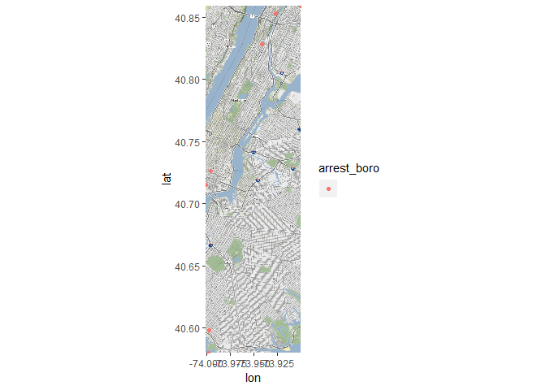

```r
rm(comb.tab)
rm(min.tab)
rm(max.tab)

## using long and lat to find out:
geo.tab = clean_dat[, arrest_boro, by = c('longitude', 'latitude')]
map =  get_map(c(left = min(geo.tab[arrest_boro == "", longitude]), bottom = min(geo.tab[arrest_boro == "", latitude]), right = max(geo.tab[arrest_boro == "", longitude]), top = max(geo.tab[arrest_boro == "", latitude])))

ggmap(map) + geom_point(data=geo.tab[arrest_boro == ""], aes(x=longitude, y=latitude, color=arrest_boro))
```

```r
rm(geo.tab)
## After this cannot really relate to a specific boro. Check how many cases are there if its small then, rather disregard for the sake of time. But, for the future reference, I may also look the longitude and latitude to impute the boro. But, this take times so just skip for now.

missing.boro.num = clean_dat[arrest_boro == "", .N] #8

# 8.. OK, get rid of them.

clean_dat = clean_dat[arrest_boro != "", ]
```

The ‘arrest_boro’ had 6 unique keys: B,K,M,Q,S,and "“. I tried to impute the”" by observing the arrest_precinct. To do so, I took a look at the min and max of the precinct values of each factor. However, there are some overlaps. In other words, they are not distinguishable merely by comparing the precinct. In addition to that, as the above map shows, I tried to locate the missing borough by plotting out the map. It seems that they are scattered all around the borough. Therefore, I decided to drop the rows.

(The number of cases with "" are only 8 observations, which is 0% of the given data. That is trivial.)

Up to this point, I have done data exploration, cleaning, and wrangling.

For the age group, there were quite a few values that cannot be utilized, for instance, ‘338’, ‘740’, and such. As one can see this number does not tell anything about the age nor age group. Hence, I re-categorized them into the unknown.

Regarding races, it was relatively clean, saying that every category makes sense; yet, I prefer not to have unknown, especially when there is a category called “Other”. So, I put them together.

Besides, I generated time-related columns: yr and yr_mon to perform yearly and monthly based analysis.

After cleaning the data, the final data that I utilized for the analysis has 4789450 of observations with 20 columns with a missing rate of 0%. In short, the following analysis is based on the 99.81% of the given data.

Lastly, I will use the the total population from the population data, which I obtained from the NYC Open Data(reference: https://data.cityofnewyork.us/City-Government/New-York-City-Population-By-Community-Districts/xi7c-iiu2) across the year.

## ANALYSIS & ANSWERING:

### **1. Has the arrest rate been decreasing from 2015-2018? Describe the trend and defend any statistical tests used to support this conclusion.**

Yet, directly using the total population has *shortcomings*, for instance, the uniformed data may mislead the result since it does *not* take the demographic differences among the neighbors into considerations such as ethnicity, social environment, economic status, and such. In the question, the definition of the arrest rate is a bit abstract. The rate could be based on the population or other variables such as race, age, borough, sex, arrest types, and such. Hence, I would also utilize the above-mentioned variables to calculate the arrest rate of each case by year as well as the total population.

Another thing that I would like to mention is that it is not clear if the difference is between the two years, 2015 and 2018 only, or the overall trend across time. To be safe, I will plot the slop chart for the difference between 2015 and 2018; and, I will plot the histogram (bar) to show the trend during the time. Before I jumped into the analysis, I would like to make the following assumption:

- Assumptions:
  - I assume that the population does *not* fluctuate across time. (This is confirmed with the 2018 NYC population data from Statista: the total population is 8,398,748 when 8,242,624 is the total population that I used across the year; reference: https://www.statista.com/statistics/799563/resident-population-of-nyc-by-race/)
  - For simplicity, I *ignore* the traits of the neighbors such as the proportion of each ethnicity, social environment, economic status, and such.
  - I presume that every case is *independent*. This also excludes multiple crime, arrest, cases of a single person.
  - Consecutive observations are *equally spaced*
  - Apply a *discrete-time* index, yearly, (even though this may only hold approximately)

For descriptive statistics, trend analysis on the overall arrest rate, arrest rate difference between 2015 and 2018, and the arrest rate of demographics - race, age group, borough, and gender - and top 5 arrest types.

##### Trend Analysis

- Methodology: Calculate the **arrest rate**, calculated by `number of arrests divided by the total population`, of each month and compare that to each other throughout the year as well as taking a close look at the monthly data.

```r
rm(dat)
total.pop = unique(pop$total)
# making sure that dates are ascending order
setorderv(x = clean_dat, cols = 'arrest_date', order = 1)

arrest.dat = clean_dat[, .N, by = c('yr_mon')]
arrest.dat = arrest.dat[, .(Rate = (N/total.pop)*100), by = yr_mon]

# creating the ts dat
ts.dat = ts(data = arrest.dat[,-1], start = c(2006,1), end = c(2018,12), frequency = 12)

# parsing only 2015 to 2018
ts.dat.window = window(ts.dat, 2015, c(2018,12))

#time(ts.dat.window)
#cycle(ts.dat.window)
cor(ts.dat.window, lag(ts.dat.window), use = 'complete.obs')
```

```
     Rate
Rate    1
```

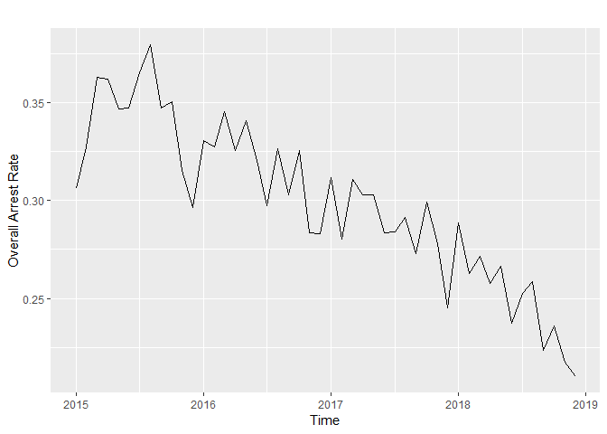

```r
autoplot(ts.dat.window, facet = T)+ ylab('Overall Arrest Rate')
```

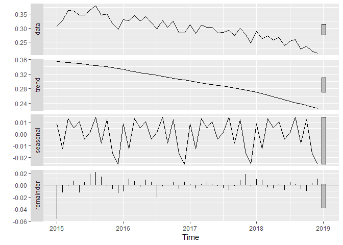

```r
# STL (Seasonality and Trend Decomposition using Loess)
autoplot(stl(ts.dat.window[,1], s.window = 'periodic', robust = T))
```

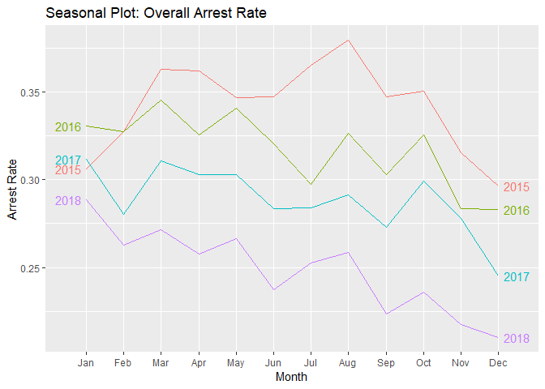

```r
# Chekcing for the seaonality
ggseasonplot(ts.dat.window, year.labels = TRUE, year.labels.left = TRUE) +
  ylab("Arrest Rate") +
  xlab("Month") +
  ggtitle("Seasonal Plot: Overall Arrest Rate") # Weak Seaonality
```

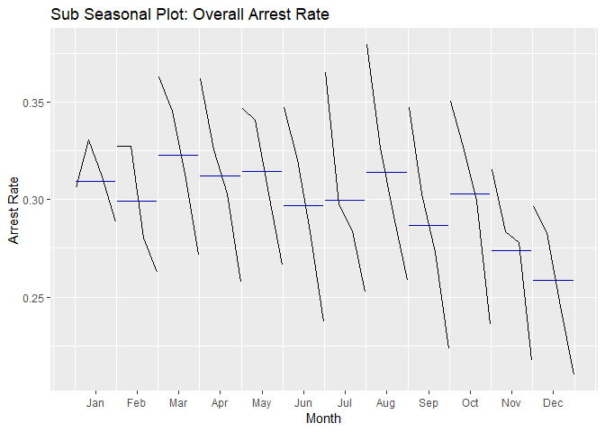

```r
# Variation by the month
ggsubseriesplot(ts.dat.window) +
  ylab("Arrest Rate") +
  xlab("Month") +
  ggtitle("Sub Seasonal Plot: Overall Arrest Rate")
```

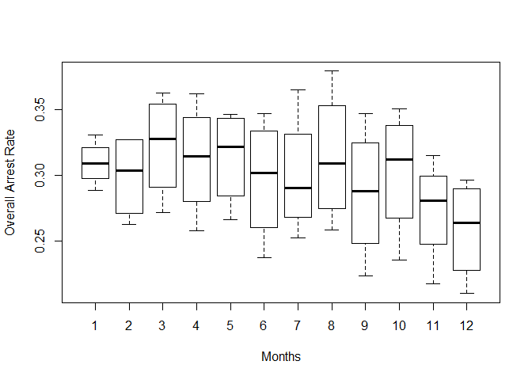

```r
boxplot(ts.dat.window~cycle(ts.dat.window), xlab = 'Months', ylab = 'Overall Arrest Rate')
```

```r
# Random Walk test:
Box.test(ts.dat.window, type = "Ljung-Box") # NOT WHITE NOISE
```

```
    Box-Ljung test

data:  ts.dat.window
X-squared = 33.041, df = 1, p-value = 9.023e-09
```

```r
# Stationary test restrict one!
adf.test(ts.dat.window, alternative="stationary", k = 0) # p = 0.01. That is, it is stationary.
```

```
    Augmented Dickey-Fuller Test

data:  ts.dat.window
Dickey-Fuller = -6.2662, Lag order = 0, p-value = 0.01
alternative hypothesis: stationary
```

```r
# Stationary around trend test
kpss.test(ts.dat.window, null = 'Trend') # p-val = 0.1, The null hypothesis of stationarity around a trend is NOT rejected.
```

```
    KPSS Test for Trend Stationarity

data:  ts.dat.window
KPSS Trend = 0.11223, Truncation lag parameter = 3, p-value = 0.1
```

```r
# White noise around trend test
kpss.test(ts.dat.window, null = 'Level') # p-val < 0.01:  The null hypothesis of stationarity around a level is rejected. That is, white noise around a trend so it is definitely a stationary process but has a trend
```

```
    KPSS Test for Level Stationarity

data:  ts.dat.window
KPSS Level = 1.186, Truncation lag parameter = 3, p-value = 0.01
```

Based on time series analysis on the overall arrest rate, one could say that the arrest rate has a **decreasing trend** with seasonality. (Note: the number of arrests has been reported in the data also decreases as the time goes)

To have a better understanding of the seasonality, I plotted out the sub seasonality plot; and, it aligns with the Seasonal Trend Decomposition using Loess (STL). Broadly speaking, the arrest rates fluctuate throughout the years; and December has the lowest arrest rate when January has the lowest variation. The lowest arrest rate in December may be explained by the Holiday season.

I took this to see the difference between the beginning year, 2015, and the end year, 2018. And, following is the results:

- Methodology: Calculating the difference between the arrest rates of only those two years: 2015 and 2018. Then, plot out the slope chart to show the relationship.

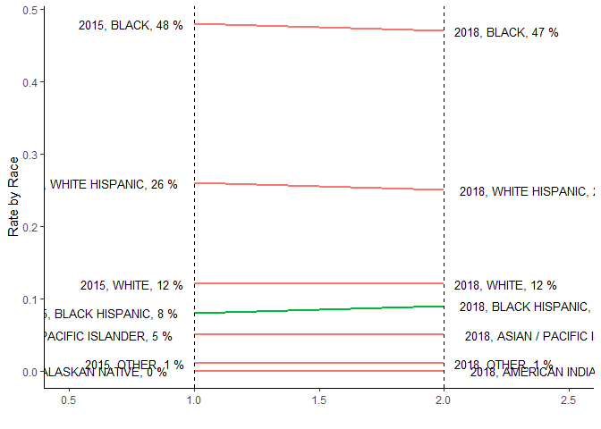

```r
# Race
rate.by.race = clean_dat[yr >= 2015, .N, by = c('yr','perp_race')]
rate.by.race[, rate := round((N / total.pop)*100, digits = 2), by = yr]
rate.by.race[, perc := round(rate / sum(rate), digits = 2), by = yr]
setorderv(rate.by.race, cols = c('yr', 'perp_race'), order = c(-1,1))
setnames(x = rate.by.race, old = 'perp_race', new = 'target')

create.slop.chart(dat = rate.by.race, title = 'Race')
```

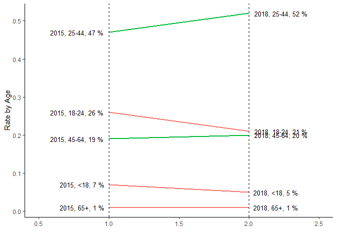

```r
# age
rate.by.age = clean_dat[yr >= 2015, .N, by = c('yr','age_group')]
rate.by.age[, rate := round((N / total.pop)*100, digits = 2), by = yr]
rate.by.age[, perc := round(rate / sum(rate), digits = 2), by = yr]
setorderv(rate.by.age, cols = c('yr', 'age_group'), order = c(-1,1))
setnames(x = rate.by.age, old = 'age_group', new = 'target')

create.slop.chart(rate.by.age, 'Age')
```

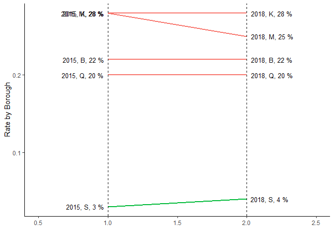

```r
# borough
rate.by.borough = clean_dat[yr >= 2015, .N, by = c('yr','arrest_boro')]
rate.by.borough[, rate := round((N / total.pop)*100, digits = 2), by = yr]
rate.by.borough[, perc := round(rate / sum(rate), digits = 2), by = yr]
setorderv(rate.by.borough, cols = c('yr', 'arrest_boro'), order = c(-1,1))
setnames(x = rate.by.borough, old = 'arrest_boro', new = 'target')

create.slop.chart(dat = rate.by.borough, 'Borough')
```

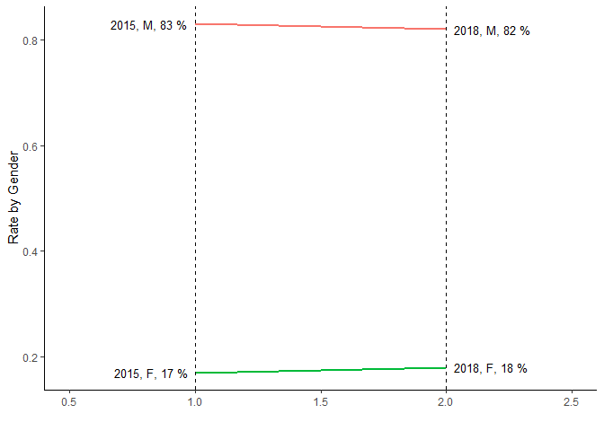

```r
# sex
rate.by.sex = clean_dat[yr >= 2015, .N, by = c('yr','perp_sex')]
rate.by.sex[, rate := round((N / total.pop)*100, digits = 2), by = yr]
rate.by.sex[, perc := round(rate / sum(rate), digits = 2), by = yr]
setorderv(rate.by.sex, cols = c('yr', 'perp_sex'), order = c(-1,1))
setnames(x = rate.by.sex, old = 'perp_sex', new = 'target')

create.slop.chart(dat = rate.by.sex, 'Gender')
```

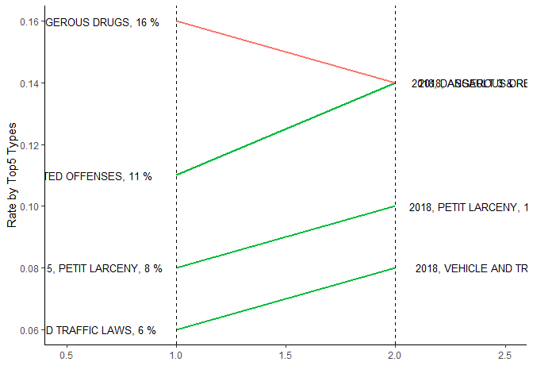

```r
# offense description
rate.by.ofns_desc = clean_dat[yr >= 2015, .N, by = c('yr','ofns_desc')]
rate.by.ofns_desc[, rate := round((N / total.pop)*100, digits = 2), by = yr]
rate.by.ofns_desc[, perc := round(rate / sum(rate), digits = 2), by = yr]
setorderv(rate.by.ofns_desc, cols = c('yr', 'perc'), order = c(-1,-1))
setnames(x = rate.by.ofns_desc, old = 'ofns_desc', new = 'target')

# take the top 5
rate.by.ofns_desc.top5 = rate.by.ofns_desc[, .SD[1:5] , by = yr]


create.slop.chart(dat = rate.by.ofns_desc.top5, 'Top5 Types')
```

The result of the slop chart shows that there is not much change between the two years for the arrest rate of race and gender, while there is an obvious difference for the age group, borough, and the offense description.

Now, I take a look at it by the yearly trend:

- Methodology: calculate the percentage of each factor of the variables: race, age group, gender, borough, and top 5 types of crime. Then, plot out the histogram of the account rates of each factor throughout the year.

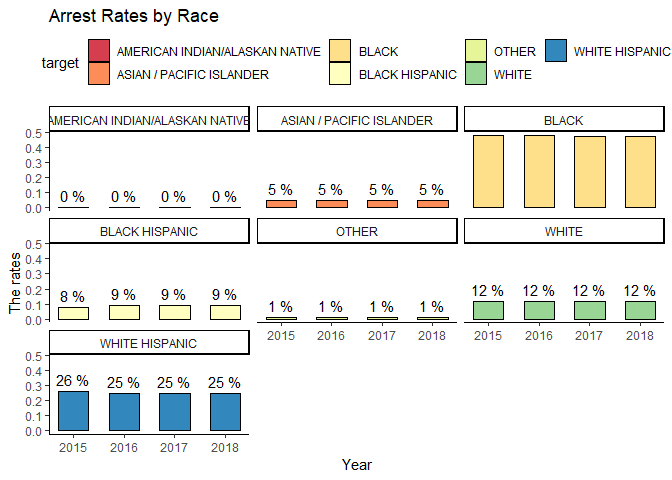

```r
# by race
create.histogram(dat = rate.by.race, title = 'Race')
```

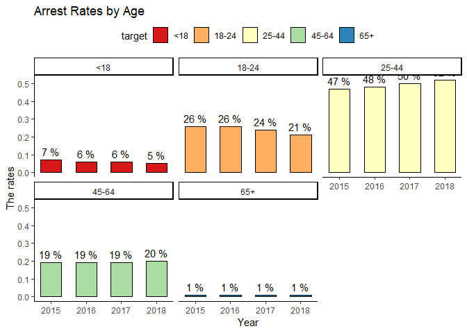

```r
# by age
create.histogram(dat = rate.by.age, title = 'Age')
```

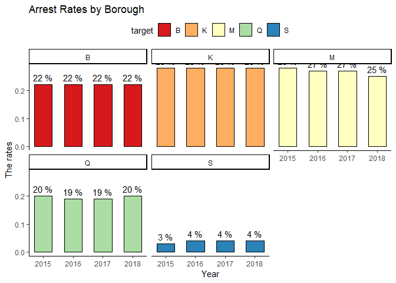

```r
# by borough
create.histogram(dat = rate.by.borough, title = 'Borough')
```

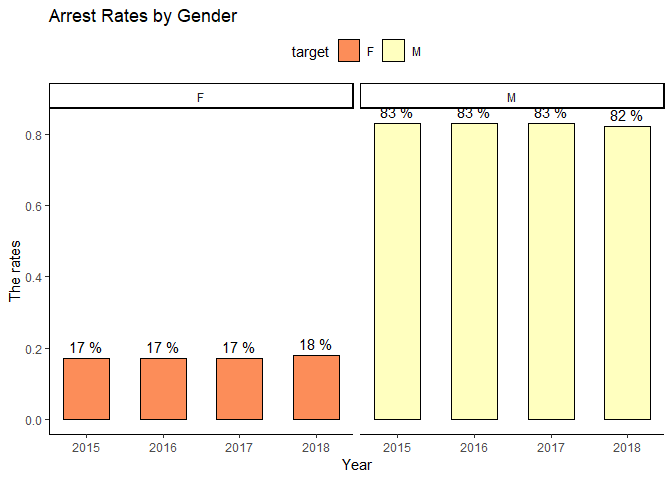

```r
# by sex
create.histogram(dat = rate.by.sex, title = 'Gender')
```

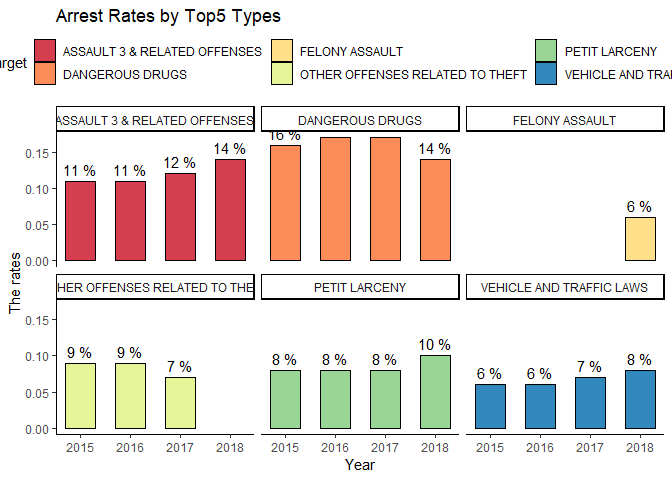

```r
# by ofns_desc
create.histogram(dat = rate.by.ofns_desc.top5, title = 'Top5 Types')
```

```r
rm(rate.by.age)
rm(rate.by.borough)
rm(rate.by.ofns_desc)
rm(rate.by.race)
rm(rate.by.sex)
```

Unlike the trend analysis on the overall arrest rate, the arrest rates based on the demographics do not show distinctive trends but stays almost the same. Still, one could see a change from the arrest rates of age group, borough, and top 5 offense descriptions: the arrest rate of the age group 25-44 increases, while that of 18-24 decreases; and, the assault 3 & related offenses and the vehicle and traffic laws increase as the times goes by, while the dangerous drugs and the other offenses related to theft are decreasing. The most interesting point from this plot would be that felony assault is raised in 2018 as one of the top 5 arrest types when other offenses related to theft is not on the list anymore.

Based on both charts, I could say that the arrest rates of the race and sex do not have any distinctive trends unlike those of the age group, borough, and the types of arrest.

In short, the overall arrest rate throughout the time shows the decreasing trend; however, the arrest rate of race, gender, age group, borough, and the top 5 arrest types shows the different results: most of the demographics based arrest rates do not change much, while the top 5 arrest types, age group, and borough display distinctive changes.

Let’s confirm with the regression analysis for the overall trend of arrest rate:

- Regression Analysis: linear regression

```r
q1.dat = clean_dat[yr >=2015 & ofns_desc %in% unique(rate.by.ofns_desc.top5$target), .N, by = c('arrest_date', 'age_group', 'perp_race', 'perp_sex', 'arrest_boro', 'ofns_desc', 'yr', 'yr_mon')]

rm(rate.by.ofns_desc.top5)

q1.dat[, Rate:= (N/total.pop)*100, by = yr]

formula = create.formula(outcome.name = 'Rate', input.names = c('age_group', 'perp_race', 'perp_sex', 'arrest_boro', 'ofns_desc', 'yr'), dat = q1.dat, max.input.categories = 7, reduce = T)

#formula2 = create.formula(outcome.name = 'N', input.names = c('age_group', 'perp_race', 'perp_sex', 'arrest_boro', 'ofns_desc', 'yr'), dat = q1.dat, max.input.categories = 7, reduce = T)

lm = lm(formula = formula, data = q1.dat)
#lm2 = lm(formula = formula2, data = q1.dat)

summary(lm)
```

```
Call:
lm(formula = formula, data = q1.dat)

Residuals:
       Min         1Q     Median         3Q        Max
-3.396e-05 -1.013e-05 -3.060e-06  5.320e-06  4.551e-04

Coefficients:
                                           Estimate Std. Error t value Pr(>|t|)
(Intercept)                               1.614e-03  5.269e-05  30.627  < 2e-16
age_group18-24                            6.298e-06  1.196e-07  52.675  < 2e-16
age_group25-44                            1.304e-05  1.151e-07 113.256  < 2e-16
age_group45-64                            5.430e-06  1.217e-07  44.629  < 2e-16
age_group65+                             -2.495e-06  2.352e-07 -10.608  < 2e-16
perp_raceASIAN / PACIFIC ISLANDER         3.634e-06  4.391e-07   8.276  < 2e-16
perp_raceBLACK                            1.682e-05  4.274e-07  39.351  < 2e-16
perp_raceBLACK HISPANIC                   3.294e-06  4.334e-07   7.602 2.93e-14
perp_raceOTHER                           -1.282e-06  4.879e-07  -2.627  0.00861
perp_raceWHITE                            5.236e-06  4.310e-07  12.148  < 2e-16
perp_raceWHITE HISPANIC                   1.013e-05  4.284e-07  23.655  < 2e-16
perp_sexM                                 9.877e-06  6.577e-08 150.171  < 2e-16
arrest_boroK                              4.582e-07  8.421e-08   5.441 5.29e-08
arrest_boroM                              8.951e-07  8.280e-08  10.810  < 2e-16
arrest_boroQ                             -3.415e-06  8.913e-08 -38.316  < 2e-16
arrest_boroS                             -8.582e-06  1.377e-07 -62.319  < 2e-16
ofns_descDANGEROUS DRUGS                  6.634e-06  8.661e-08  76.598  < 2e-16
ofns_descFELONY ASSAULT                  -5.999e-06  1.033e-07 -58.068  < 2e-16
ofns_descOTHER OFFENSES RELATED TO THEFT -1.197e-06  1.038e-07 -11.537  < 2e-16
ofns_descPETIT LARCENY                   -2.500e-06  9.213e-08 -27.132  < 2e-16
ofns_descVEHICLE AND TRAFFIC LAWS        -4.390e-06  9.996e-08 -43.916  < 2e-16
yr                                       -8.014e-07  2.613e-08 -30.671  < 2e-16

(Intercept)                              ***
age_group18-24                           ***
age_group25-44                           ***
age_group45-64                           ***
age_group65+                             ***
perp_raceASIAN / PACIFIC ISLANDER        ***
perp_raceBLACK                           ***
perp_raceBLACK HISPANIC                  ***
perp_raceOTHER                           **
perp_raceWHITE                           ***
perp_raceWHITE HISPANIC                  ***
perp_sexM                                ***
arrest_boroK                             ***
arrest_boroM                             ***
arrest_boroQ                             ***
arrest_boroS                             ***
ofns_descDANGEROUS DRUGS                 ***
ofns_descFELONY ASSAULT                  ***
ofns_descOTHER OFFENSES RELATED TO THEFT ***
ofns_descPETIT LARCENY                   ***
ofns_descVEHICLE AND TRAFFIC LAWS        ***
yr                                       ***
---
Signif. codes:  0 '***' 0.001 '**' 0.01 '*' 0.05 '.' 0.1 ' ' 1

Residual standard error: 1.696e-05 on 350946 degrees of freedom
Multiple R-squared:  0.2215,    Adjusted R-squared:  0.2214
F-statistic:  4754 on 21 and 350946 DF,  p-value: < 2.2e-16
```

```r
#summary(lm2)


# this is based on the simple linear regression.
#ggplot(q1.dat, aes(x = yr, y = Rate)) +
#  geom_point() +
#  stat_smooth(method = "lm", col = "red")

rm(q1.dat)
```

As an extension of descriptive statistics, I performed a multivariate linear regression with the following formula:
$$Rate = b_1AgeGroup + b_2Race + b_3Gender + b_4Borough+ b_5Types + b_6Year$$

The result of the linear regression also states that the arrest rates are decreasing as across the time holding the above-mentioned variable fixed. Controlling for other variables, one year increase in year would decrease the arrest rate by -8.014e-07 on average.

### **2. What are the top 5 most frequent arrests as described in the column ‘pd_desc’ in 2018? Compare & describe the overall trends of these arrests across time.**

I break the question into two parts: figuring out the top 5 pd_desc in 2018 and looking for the trend.

- Part one: figuring out the top 5 arrests in 2018.

**Here, the question asked about the frequency, which I take it as the number of occurrences, instead of rate. That is, the following analysis is based on the absolute number rather than the rate, calculated by frequency/population**

```r
pd_desc.num = length(unique(clean_dat$pd_desc))
pd_desc.uniq = unique(clean_dat$pd_desc)

tab = clean_dat[yr == 2018, .N, by = pd_desc][order(-N)]
tab[, perc := round(N / sum(N) *100, digits = 2)]

datatable(tab[1:5], rownames = F)
```

| pd_desc | N | perc |
| --- | --- | --- |
| ASSAULT 3 | 26611 | 10.82 |
| LARCENY,PETIT FROM OPEN AREAS,UNCLASSIFIED | 23405 | 9.52 |
| TRAFFIC,UNCLASSIFIED MISDEMEAN | 14856 | 6.04 |
| ASSAULT 2,1,UNCLASSIFIED | 11763 | 4.78 |
| CONTROLLED SUBSTANCE, POSSESSION 7 | 9982 | 4.06 |

```r
#rm(tab)
```

There are 351 types of arrests in the column. Yet, there are 304 number of the arrest types.

As the above table shows, the top 5 pd_desc types in 2018 are Assult 3, Larceny Petit From Open Areas, Traffic, Assault 2&1, and Controlled Substance.

- Side: I wanted to check if the monthly top 5 types consistent with the year based.

```r
#rm(tab)

tab.mon = clean_dat[yr == 2018, .N, by = c('pd_desc','yr_mon' )]
tab.mon[, perc := round(N / sum(N) *100, digits = 2), by = 'yr_mon']
setorderv(tab.mon, cols = c('yr_mon', 'perc'), order = c(-1,-1))

tab.mon.top.5 = tab.mon[, .SD[1:5], by = yr_mon]

datatable(tab.mon.top.5,rownames = F)
```

| yr_mon | pd_desc | N | perc |
| --- | --- | --- | --- |
| 2018-12 | LARCENY,PETIT FROM OPEN AREAS,UNCLASSIFIED | 2014 | 11.62 |
| 2018-12 | ASSAULT 3 | 1941 | 11.2 |
| 2018-12 | TRAFFIC,UNCLASSIFIED MISDEMEAN | 996 | 5.75 |
| 2018-12 | ASSAULT 2,1,UNCLASSIFIED | 831 | 4.8 |
| 2018-12 | CONTROLLED SUBSTANCE, POSSESSION 7 | 736 | 4.25 |
| 2018-11 | ASSAULT 3 | 1984 | 11.07 |
| 2018-11 | LARCENY,PETIT FROM OPEN AREAS,UNCLASSIFIED | 1876 | 10.47 |
| 2018-11 | TRAFFIC,UNCLASSIFIED MISDEMEAN | 989 | 5.52 |
| 2018-11 | ASSAULT 2,1,UNCLASSIFIED | 852 | 4.75 |
| 2018-11 | CONTROLLED SUBSTANCE, POSSESSION 7 | 761 | 4.25 |

[output cut: 50 more lines]

```r
datatable(tab.mon.top.5[, .N, by = pd_desc])
```

|  | pd_desc | N |
| --- | --- | --- |
| 1 | LARCENY,PETIT FROM OPEN AREAS,UNCLASSIFIED | 12 |
| 2 | ASSAULT 3 | 12 |
| 3 | TRAFFIC,UNCLASSIFIED MISDEMEAN | 12 |
| 4 | ASSAULT 2,1,UNCLASSIFIED | 10 |
| 5 | CONTROLLED SUBSTANCE, POSSESSION 7 | 7 |
| 6 | ROBBERY,UNCLASSIFIED,OPEN AREAS | 1 |
| 7 | MARIJUANA, POSSESSION 4 &amp; 5 | 5 |
| 8 | THEFT OF SERVICES, UNCLASSIFIED | 1 |

```r
rm(tab.mon.top.5)
```

The above table shows that the yearly top 5 arrest type in 2018 aligns with that of monthly top 5 types of that year.

- Part two: compare and describe the overall trends of these types over the time

```r
top.5.pd_desc = tab[, pd_desc][1:5]

# parsing the top 5 from the overall data
comparison.tab = clean_dat[pd_desc %in% top.5.pd_desc, .N, by = c('yr','pd_desc')]

comparison.tab[, perc := round(N / sum(N), digits = 2), by = yr]
setorderv(comparison.tab, cols = c('yr', 'perc'), order = c(-1,-1))
comparison.tab[, rank:= 1:.N, by = yr]
comparison.tab[, diff:= rank - shift(rank), by = pd_desc]
datatable(comparison.tab, rownames = F)
```

| yr | pd_desc | N | perc | rank | diff |
| --- | --- | --- | --- | --- | --- |
| 2018 | ASSAULT 3 | 26611 | 0.31 | 1 |  |
| 2018 | LARCENY,PETIT FROM OPEN AREAS,UNCLASSIFIED | 23405 | 0.27 | 2 |  |
| 2018 | TRAFFIC,UNCLASSIFIED MISDEMEAN | 14856 | 0.17 | 3 |  |
| 2018 | ASSAULT 2,1,UNCLASSIFIED | 11763 | 0.14 | 4 |  |
| 2018 | CONTROLLED SUBSTANCE, POSSESSION 7 | 9982 | 0.12 | 5 |  |
| 2017 | ASSAULT 3 | 26281 | 0.29 | 1 | 0 |
| 2017 | LARCENY,PETIT FROM OPEN AREAS,UNCLASSIFIED | 23020 | 0.26 | 2 | 0 |
| 2017 | TRAFFIC,UNCLASSIFIED MISDEMEAN | 16298 | 0.18 | 3 | 0 |
| 2017 | CONTROLLED SUBSTANCE, POSSESSION 7 | 12341 | 0.14 | 4 | -1 |
| 2017 | ASSAULT 2,1,UNCLASSIFIED | 11911 | 0.13 | 5 | 1 |

[output cut: 55 more lines]

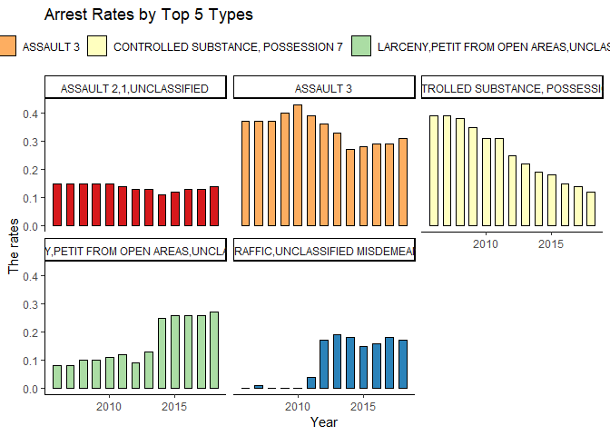

```r
setnames(x = comparison.tab, old = 'pd_desc', new = 'target')

create.histogram(dat = comparison.tab, title = 'Top 5 Types', show.labels = F)
```

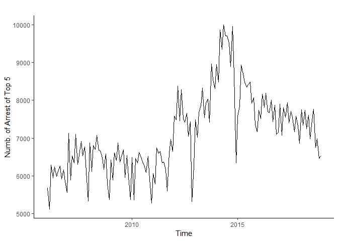

```r
## overal time series
top.5.dat = clean_dat[pd_desc %in% top.5.pd_desc, .N, by = c( 'yr_mon')]
#top.5.dat = top.5.dat[, mean:= mean(N), by = c('yr_mon')]

top.ts = ts(data = top.5.dat[,-1], start = c(2006,1), end = c(2018,12), frequency = 12)

autoplot(top.ts, facet = T)+ ylab('Numb. of Arrest of Top 5')
```

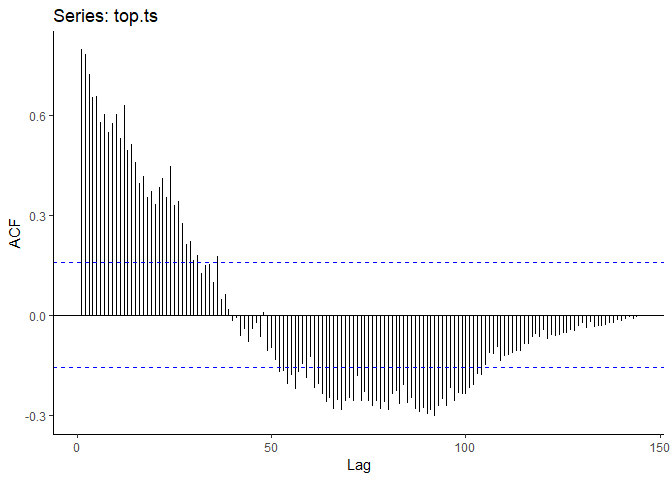

```r
ggAcf(x = top.ts, lag.max = 12*12)
```

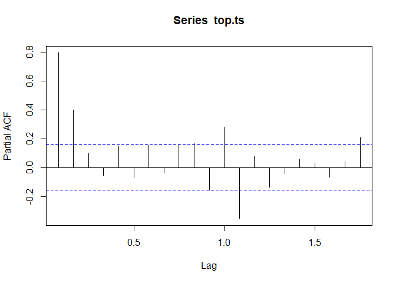

```r
pacf(top.ts)
```

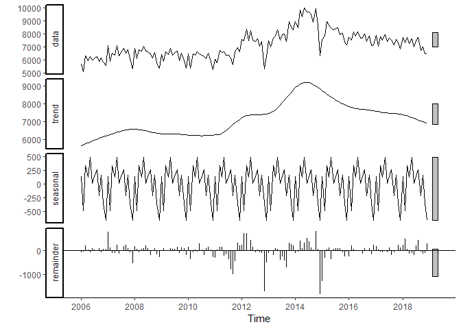

```r
# it is highly auto-correlated with the adjecent year and the year before with high seasonality

# STL (Seasonality and Trend Decomposition using Loess)
autoplot(stl(top.ts[,1], s.window = 'periodic', robust = T))
```

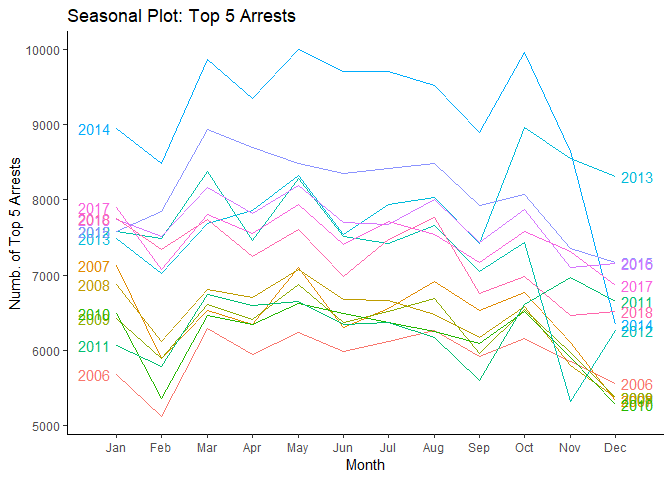

```r
# Chekcing for the seaonality
ggseasonplot(top.ts, year.labels = TRUE, year.labels.left = TRUE) +
  ylab("Numb. of Top 5 Arrests") +
  xlab("Month") +
  ggtitle("Seasonal Plot: Top 5 Arrests")
```

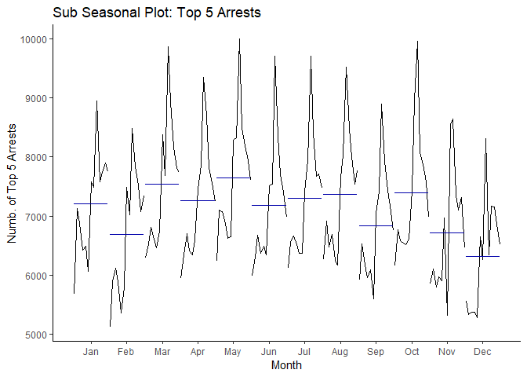

```r
# Variation by the month
ggsubseriesplot(top.ts) +
  ylab("Numb. of Top 5 Arrests") +
  xlab("Month") +
  ggtitle("Sub Seasonal Plot: Top 5 Arrests")
```

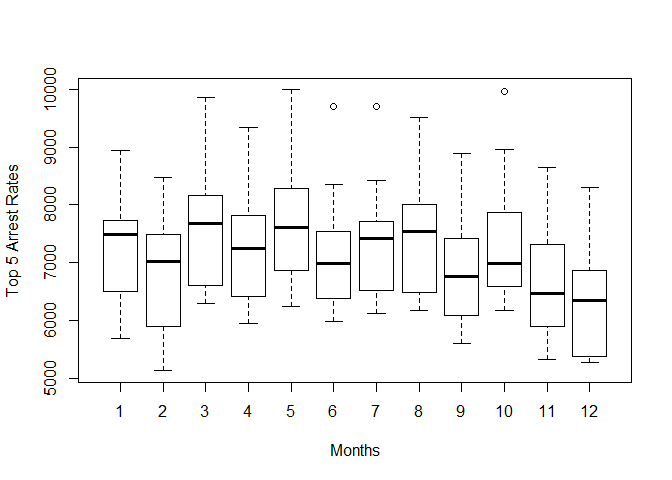

```r
boxplot(top.ts~cycle(top.ts), xlab = 'Months', ylab = 'Top 5 Arrest Rates')
```

```r
# Stationary test
adf.test(top.ts, alternative="stationary") # p = 0.5. That is, it is not stationary.
```

```
    Augmented Dickey-Fuller Test

data:  top.ts
Dickey-Fuller = -2.2448, Lag order = 5, p-value = 0.4743
alternative hypothesis: stationary
```

```r
# Stationary around trend test
kpss.test(top.ts, null = 'Trend', lshort = F) # p-val = 0.04, The significant test statistic indicates that it is not stationarity .
```

```
    KPSS Test for Trend Stationarity

data:  top.ts
KPSS Trend = 0.15154, Truncation lag parameter = 13, p-value = 0.04538
```

```r
# White noise around trend test
kpss.test(top.ts, null = 'Level', lshort = F) # p-val < 0.05:  The null hypothesis of stationarity around a level is rejected. That is, not a stationary.
```

```
    KPSS Test for Level Stationarity

data:  top.ts
KPSS Level = 0.72144, Truncation lag parameter = 13, p-value = 0.0116
```

On the other hand, the arrest frequency of the Controlled Substance, Possession 7 type is decreasing from 39% to 12%. Until 2015, it was rated as top 3 arrest types; nevertheless, it has made its progress that it is enlisted on bottom 2 since then.

Regarding the overall trend of the top 5 arrest types, one could say that the trend is moving from increasing to decreasing starting from 2014 and that there is a high seasonality. Lastly, December is the month that has the lowest arrest rates throughout the years, when May has the highest.

Still, one could say that the **frequency** of those top 5 types is **increased** due to the fact that the mean of overall number of arrests of those types is increased compared to that of the beginning year. This could be supported by the the plot as followed:

```r
q2.dat = clean_dat[pd_desc %in% top.5.pd_desc, .N, by = c('yr','pd_desc', 'arrest_date', 'yr_mon')]

q2.dat[, mean:= mean(N), by = yr_mon]

formula2 = create.formula(outcome.name = 'mean', input.names = c('yr', 'pd_desc'), dat = q2.dat)

lm2 = lm(formula = formula2, data = q2.dat)
summary(lm2)
```

```
Call:
lm(formula = formula2, data = q2.dat)

Residuals:
    Min      1Q  Median      3Q     Max
-14.249  -2.703  -0.651   2.034  14.411

Coefficients:
                                                    Estimate Std. Error t value
(Intercept)                                       -6.503e+02  1.827e+01 -35.605
yr                                                 3.479e-01  9.078e-03  38.320
pd_descASSAULT 3                                   4.314e-12  1.021e-01   0.000
pd_descCONTROLLED SUBSTANCE, POSSESSION 7          2.554e-03  1.021e-01   0.025
pd_descLARCENY,PETIT FROM OPEN AREAS,UNCLASSIFIED  4.316e-12  1.021e-01   0.000
pd_descTRAFFIC,UNCLASSIFIED MISDEMEAN              1.629e-01  1.130e-01   1.441
                                                  Pr(>|t|)
(Intercept)                                         <2e-16 ***
yr                                                  <2e-16 ***
pd_descASSAULT 3                                      1.00
pd_descCONTROLLED SUBSTANCE, POSSESSION 7             0.98
pd_descLARCENY,PETIT FROM OPEN AREAS,UNCLASSIFIED     1.00
pd_descTRAFFIC,UNCLASSIFIED MISDEMEAN                 0.15
---
Signif. codes:  0 '***' 0.001 '**' 0.01 '*' 0.05 '.' 0.1 ' ' 1

Residual standard error: 4.976 on 22349 degrees of freedom
Multiple R-squared:  0.06391,   Adjusted R-squared:  0.0637
F-statistic: 305.2 on 5 and 22349 DF,  p-value: < 2.2e-16
```

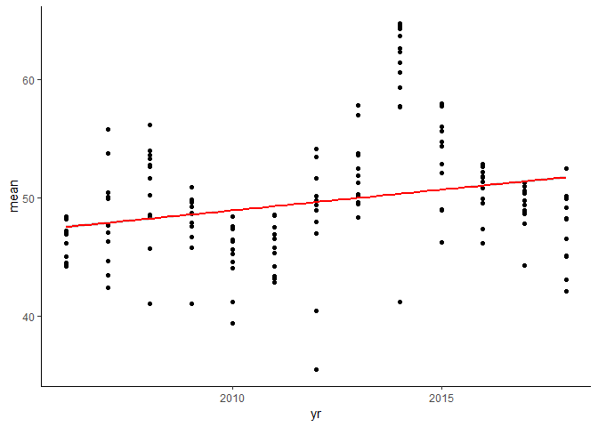

```r
ggplot(q2.dat, aes(x = yr, y = mean)) +
  geom_point() +
  stat_smooth(method = "lm", col = "red")
```

```r
rm(q2.dat)
```

### **3. If we think of arrests as a sample of total crime, is there more crime in precinct 19 (Upper East Side) than precinct 73 (Brownsville)? Describe the trend, variability and justify any statistical tests used to support this conclusion.**

The question mentioned that the data, sample, could represent the total crime. That is, it is a representative sample that allows me to draw a conclusion of the population based on the analysis of the sample with confidence. Say that, number of arrests can represent the crime rates. With that in mind, the analysis is conducted.

**As a side note: The overall crime rate in Brownsville, precinct 73, is 16% higher than the national average, while the overall crime rate in Upper East Side, precinct 19, is 28% lower than the national average. (reference: https://www.areavibes.com/brownsville-tx/crime/)**

- Methodology: calculate the **monthly mean of arrests** of each precinct across the year, then compute the **difference** between them. And, plot out the difference by year. Here, I took the mean difference to alleviate the difference between the two districts as well as the difference across the time.
- Computing mean of arrest

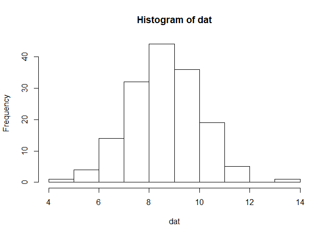

```
$breaks
 [1]  4  5  6  7  8  9 10 11 12 13 14

$counts
 [1]  1  4 14 32 44 36 19  5  0  1

$density
 [1] 0.006410256 0.025641026 0.089743590 0.205128205 0.282051282 0.230769231
 [7] 0.121794872 0.032051282 0.000000000 0.006410256

$mids
 [1]  4.5  5.5  6.5  7.5  8.5  9.5 10.5 11.5 12.5 13.5

$xname
[1] "dat"

$equidist
[1] TRUE

attr(,"class")
[1] "histogram"
```

```
       0%       25%       50%       75%      100%
 4.933333  7.793548  8.426344  9.620968 13.866667
```

```r
# parsing 19
tab.19 = clean_dat[arrest_precinct == 19, .N, by = c('arrest_date','arrest_precinct', 'yr_mon')]
# compute the arrest rate by mean of month
tab.19 = tab.19[, mean(N), by= yr_mon]
setnames(x = tab.19, old = 'V1', new = '19')

# parsing 73
tab.73 = clean_dat[arrest_precinct == 73, .N, by = c('arrest_date','arrest_precinct','yr_mon')]
# compute the arrest rate by mean of month
tab.73 = tab.73[, mean(N), by= yr_mon]
setnames(x = tab.73, old = 'V1', new = '73')

tab.19.73 = merge(tab.19, tab.73, by = 'yr_mon')

basic.stat(tab.19.73$`19`)
```

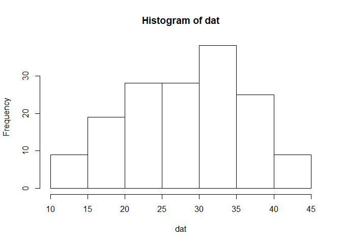

```
$breaks
[1] 10 15 20 25 30 35 40 45

$counts
[1]  9 19 28 28 38 25  9

$density
[1] 0.01153846 0.02435897 0.03589744 0.03589744 0.04871795 0.03205128 0.01153846

$mids
[1] 12.5 17.5 22.5 27.5 32.5 37.5 42.5

$xname
[1] "dat"

$equidist
[1] TRUE

attr(,"class")
[1] "histogram"
```

```
      0%      25%      50%      75%     100%
12.20000 22.33280 29.08333 34.48871 43.87097
```

```r
basic.stat(tab.19.73$`73`)
```

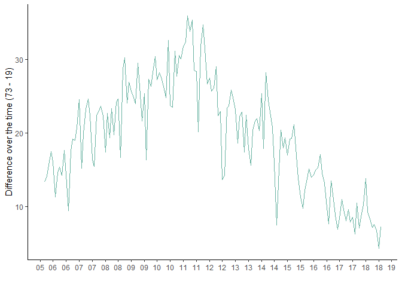

```r
#cor(tab.19.73$`19`, tab.19.73$`73`)

tab.19.73[, mean_diff := `73` - `19`, by = yr_mon]

ggplot(tab.19.73, aes(x=as.Date(paste0(yr_mon,"-01")), y=mean_diff)) +
  geom_line(color = '#69b3a2')+
  xlab("") +
  ylab("Difference over the time (73 - 19)")+
  scale_x_date(date_breaks = "6 month", date_labels = "%y")
```

Answering the first part of the question, precinct 73 has a higher average number of crime than precinct 19 across the time on average throughout the year. And, this aligns with the aforementioned reference. It claims that precinct 73 has higher crime rates than the national average, while precinct 19 has fewer crime rats than that.

To have a better understanding of the impact of the locales, I took a regression analysis. And, the following is the result:

```r
q3.dat = clean_dat[arrest_precinct == 19 | arrest_precinct == 73, .N, by = c('yr', 'arrest_date', 'yr_mon', 'arrest_precinct')]

q3.dat[, mean := mean(N), by = yr_mon]
q3.dat$arrest_precinct = as.factor(q3.dat$arrest_precinct)

formula3 = create.formula(outcome.name = 'mean', input.names = c('yr', 'arrest_precinct'), dat = q3.dat)

lm3 = lm(formula = formula3, data = q3.dat)
summary(lm3)
```

```
Call:
lm(formula = formula3, data = q3.dat)

Residuals:
    Min      1Q  Median      3Q     Max
-7.6214 -2.8034 -0.1228  2.6316  7.1568

Coefficients:
                    Estimate Std. Error t value Pr(>|t|)
(Intercept)        1.458e+03  1.884e+01  77.424   <2e-16 ***
yr                -7.156e-01  9.362e-03 -76.443   <2e-16 ***
arrest_precinct73 -5.429e-03  7.006e-02  -0.077    0.938
---
Signif. codes:  0 '***' 0.001 '**' 0.01 '*' 0.05 '.' 0.1 ' ' 1

Residual standard error: 3.409 on 9469 degrees of freedom
Multiple R-squared:  0.3816,    Adjusted R-squared:  0.3815
F-statistic:  2922 on 2 and 9469 DF,  p-value: < 2.2e-16
```

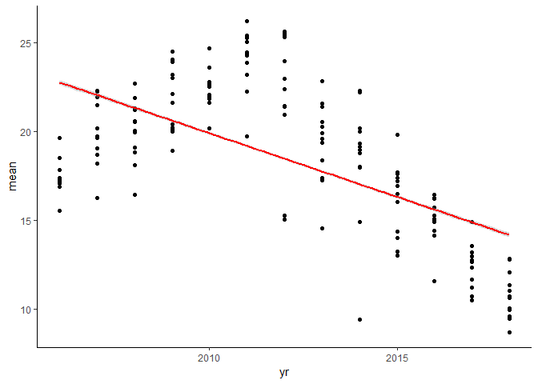

```r
ggplot(q3.dat, aes(x = yr, y = mean)) +
  geom_point() +
  stat_smooth(method = "lm", col = "red")
```

```r
rm(q3.dat)
```